# POLI 572B

Michael Weaver

March 3, 2023

# Least Squares

### Objectives

**Matrix Algebra**

- Key mathematical operations
- Geometric intuition

**Deriving Multivariate Least Squares**

- Relationship to the mean
- Minimizing distance
- Relationship to correlation

### Today

- algorithm with mathematical properties
  - what are the assumptions and properties and why
- without further assumption, plug in data, generate a line
- limited interpretation

### Today

- Matrix algebra
- The Mean
- Derive Least Squares algorithm
- Multiple Regression requirements, interpretation

### Regression as Prediction

We can treat regression as a way of **predicting** values of $Y$, given values of $X$ (or choosing a constant - the mean)

We obtain least squares regression by imposing the requirement that the (Euclidean) **distance** between our prediction and and the true values of $Y$ is as small as possible.

### Bivariate Regression

To predict $y$ as a linear function of $x$:

$\widehat{y}_i = a + b x_i$

#### slope:

$$b = \frac{Cov(x,y)}{Var(x)}$$

#### intercept:

$$a = \overline{y} - \overline{x}\cdot
b$$

### Bivariate Regression

**Fitted/Predicted Values**

$$\widehat{y_i} = a + b \cdot
x_i$$

**Residuals** (prediction errors)

$$y_i - \widehat{y}_i = e_i$$

### Two “assumptions”

In order for calculations of least squares to be possible, two things must be true:

1. $Var(x) \neq 0$
- Recall $b = \frac{Cov(x,y)}{Var(x)}$, so undefined if $Var(x) = 0$
2. $n >= 2$, at least as many observations as coefficients to find ($a,b$).

### Two “properties”

By choosing $a$ and $b$ to minimize distance between $Y$ and $\widehat{Y}$ the following are necessarily true:

1. **the mean of the residuals is always zero** if we include an intercept ($a$); this is true of the mean as well.
2. $Cov(X,e) = 0$. This is true by definition of how we derived least squares.

# Matrix Algebra

### What is a vector?

- a **vector** is a one-dimensional array of numbers. It is $n \times 1$ or $1 \times n$.

$$y = \begin{pmatrix}3 \\ 5
\end{pmatrix}$$

- a **matrix** is a rectangular array of numbers. $X$ is a $3 \times 2$ matrix. $3$ rows and $2$ columns.

$$X = \begin{pmatrix} 1 & -1 \\ 1
& 2 \\ 1 & 4 \end{pmatrix}$$

**Vectors have geometric interpretation** (matrices are groups of vectors)

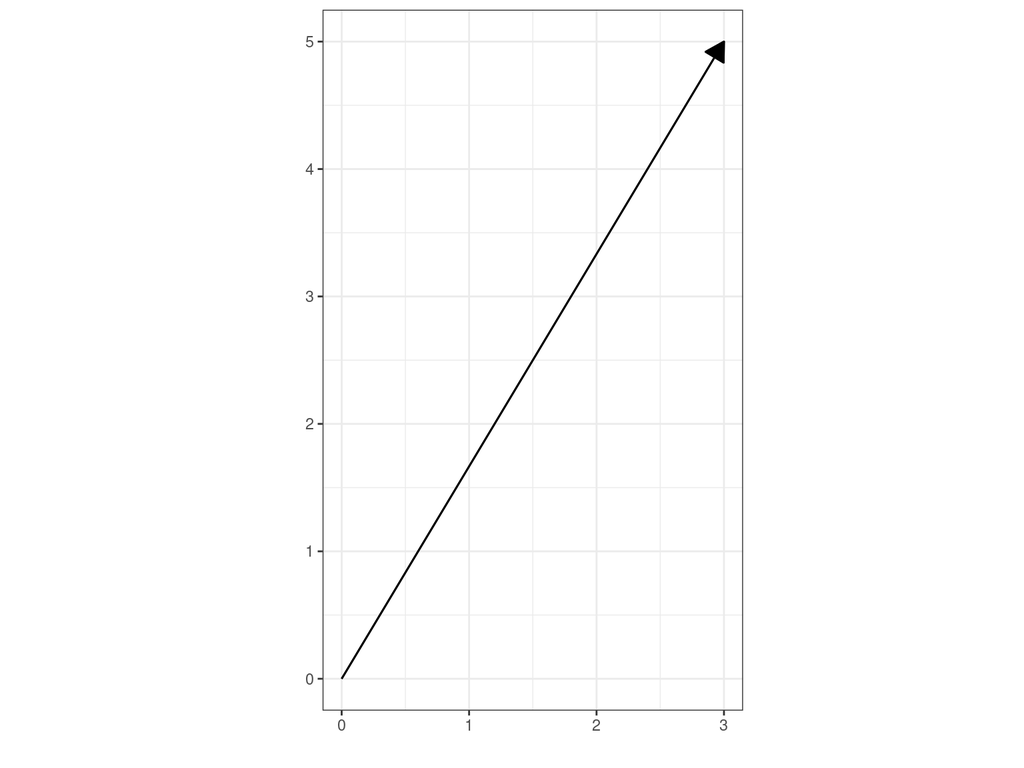

### Vectors Can be Added

Matrices and vectors of the **same dimensions** can be added or subtracted element-by-element.

For example:

$$\begin{pmatrix}1 \\ 1 \end{pmatrix} +
\begin{pmatrix}-2 \\ 3 \end{pmatrix} = \begin{pmatrix}-1 \\ 4
\end{pmatrix}$$

### Vectors Can be Added

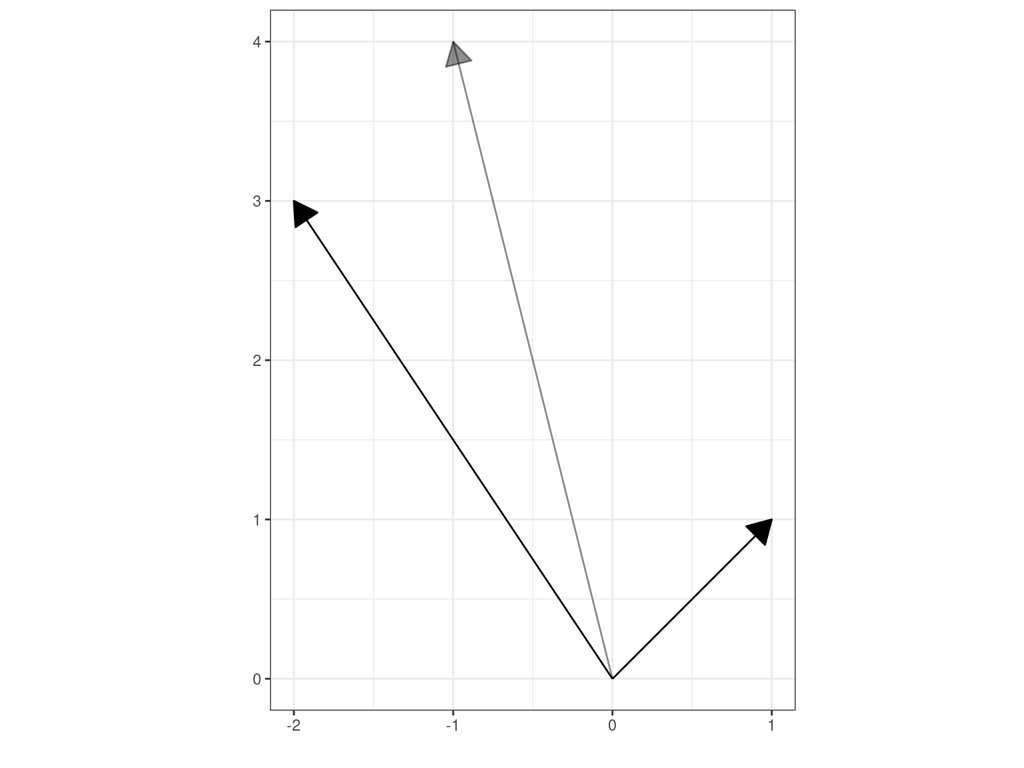

### Vectors Can be Multiplied

Vectors are matrices with a single column (or row). **scalars** are $1 \times 1$ matrices

- Matrices/vectors can be multiplied (element-by-element) by a scalar.

$$2.5 \cdot \begin{pmatrix}1 \\ 1
\end{pmatrix} = \begin{pmatrix} 2.5 \\ 2.5 \end{pmatrix}$$

$$0.5 \cdot \begin{pmatrix}-2 \\ 3
\end{pmatrix} = \begin{pmatrix} -1 \\ 1.5 \end{pmatrix}$$

$a = 2.5 \cdot \begin{pmatrix}1 \\ 1 \end{pmatrix} = \begin{pmatrix} 2.5 \\ 2.5 \end{pmatrix}; \ b = 0.5 \cdot \begin{pmatrix}-2 \\ 3 \end{pmatrix} = \begin{pmatrix} -1 \\ 1.5 \end{pmatrix}$

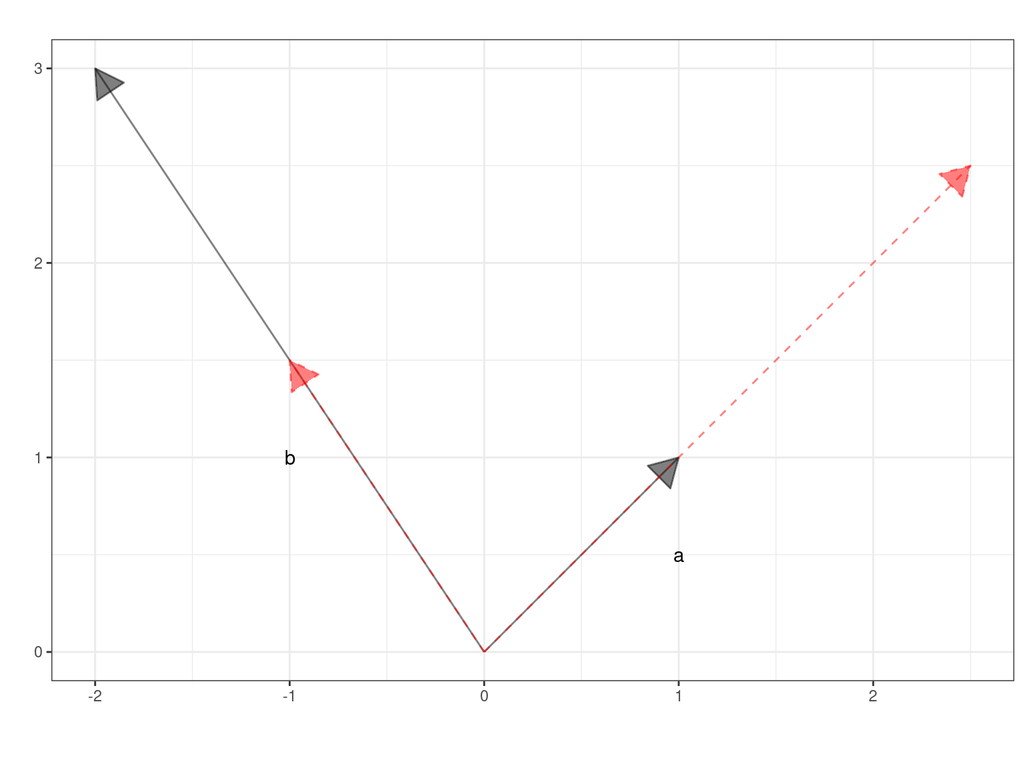

### Vectors and Matrices can be transposed:

**transposition**: rotate a matrix/vector so that columns turn into rows and vice versa:

$$u = \begin{pmatrix} 1 \\ 5 \\ -2
\end{pmatrix}$$

$$u^T = u' = \begin{pmatrix} 1 & 5
& -2 \end{pmatrix}$$

### Inner Products

If $u$ and $v$ are $n \times 1$ vectors, the **inner product** or **dot product** of $u \bullet v = u' \times v$; $u'$ is **transpose** of $u$.

$$u = \begin{pmatrix} 1 \\ -2
\end{pmatrix}; \ v =\begin{pmatrix} 4 \\ 2 \end{pmatrix}$$

$$u \bullet v = \begin{pmatrix} 1 & -2
\end{pmatrix} \begin{pmatrix} 4 \\ 2 \end{pmatrix} = 0$$

### Inner Products

First element in $u$ times first element in $v$, plus

Second element in $u$ times second element in $v$, plus

Third element in $u$ times third element in $v$, plus…

etc.

When the inner product of two vectors ($u,v$) is $0$, then $u$ and $v$ are **orthogonal**: $u \perp v$

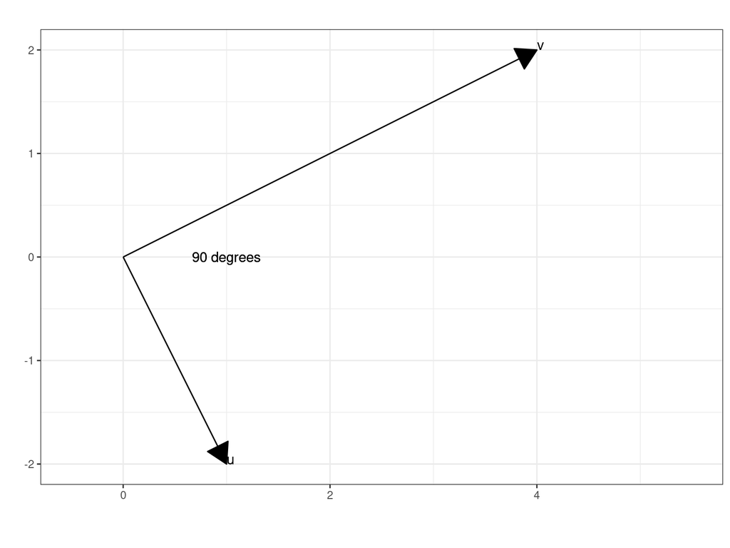

### Matrices can be Multiplied

If matrices must have dimensions that match, can be multiplied

- $m \times n$ matrix $A$ can be multiplied by matrix $B$ if $B$ is $n \times p$.
- Matrix $AB$ is $m \times p$
- Rows of $A$ multiplied with columns of $B$ and then summed: like inner product
- Multiplication not commutative: cannot multiply $BA$
- Multiplication not commutative: $B'A' = (AB)' \neq AB$

### Matrices can be Multiplied

$$\begin{pmatrix} 1 & 1 \\ -1 & 2
\end{pmatrix} \times \begin{pmatrix} 1 & -1 \\ 1 & 2
\end{pmatrix} =$$

$$\begin{pmatrix} (1 \cdot 1)+(1\cdot1)
& (1\cdot-1) + (1 \cdot 2) \\ (-1\cdot1) + (2\cdot1) &
(-1\cdot-1) + (2\cdot2) \end{pmatrix} =$$

$$= \begin{pmatrix} 2 & 1 \\ 1 &
5 \end{pmatrix}$$

### Matrices can be Divided

This is known as **inverting** a matrix.

- Inverse $A^{-1}$ of matrix $A$ that is **square** or $p\times p$ has the property:

$$A \times A^{-1} = A^{-1} \times A = I_{p
\times p} = \begin{pmatrix} 1 & 0 & \ldots & 0 \\ 0 &
\ddots & \ldots & 0 \\ 0 & \ldots & \ddots & 0 \\ 0
& \ldots & 0 & 1 \end{pmatrix}$$

This is an **identity** matrix with 1s on diagonal, 0s everywhere else. $A_{p \times p} \times I_{p \times p} = A$ (identity matrix is matrix equivalent of 1)

### Examples/ Practice

$$A = \begin{pmatrix} 1 & 5 \\ 1
& 7 \\ 1 & 8 \\ 1 & 11 \end{pmatrix}$$

Find

$$A'A = ?$$

$$AA' = ?$$

### Examples/ Practice

$$A = \begin{pmatrix} 1 & 5 \\ 1
& 7 \\ 1 & 8 \\ 1 & 11 \end{pmatrix}; B = \begin{pmatrix} 6
\\ 5 \\ 3 \\ -1 \end{pmatrix}$$

Find

$$A'B = ?$$

$$AB = ?$$

### Examples/ Practice

$$u = \begin{pmatrix} 1 \\ -2 \\ 6
\end{pmatrix}; \ v =\begin{pmatrix} 1 \\ 1 \\ 1 \end{pmatrix}$$

And

$$(u - a) \cdot v = 0$$

Solve for $a$

# Mean Again:

### Deriving the mean:

Imagine we have a variable $Y$ that we observe as a sample of size $n$. We can represent this variable as a **vector** in $n$ dimensional space.

$$y = \begin{pmatrix} 3 \\ 5
\end{pmatrix}$$

### Deriving the mean:

We want to pick one number (a scalar) $\hat{y}$ to predict all of the values in our vector $y$.

This is equivalent to doing this:

$$y = \begin{pmatrix}3 \\ 5 \end{pmatrix}
\approx \begin{pmatrix}\hat{y} \\ \hat{y} \end{pmatrix} = \hat{y}
\begin{pmatrix}1 \\ 1 \end{pmatrix}$$

Multiplying a (1,1) vector by a constant.

Choose $\hat{y}$ on the blue line at point that **minimizes** the distance to $y$.

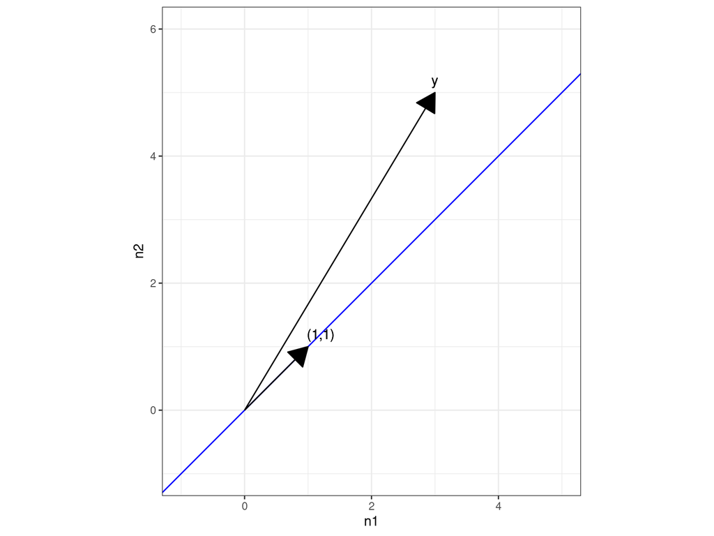

### Deriving the mean:

$y = \begin{pmatrix}3 \\ 5 \end{pmatrix}$

can be decomposed into two separate vectors: a vector containing our prediction ($\hat{y}$):

$\begin{pmatrix} \hat{y} \\ \hat{y} \end{pmatrix} = \hat{y} \begin{pmatrix} 1 \\ 1 \end{pmatrix}$

and another vector $\mathbf{e}$, which is difference between the prediction vector and the vector of observations:

$\mathbf{e} = \begin{pmatrix}3 \\ 5 \end{pmatrix} - \begin{pmatrix} \hat{y} \\ \hat{y} \end{pmatrix}$

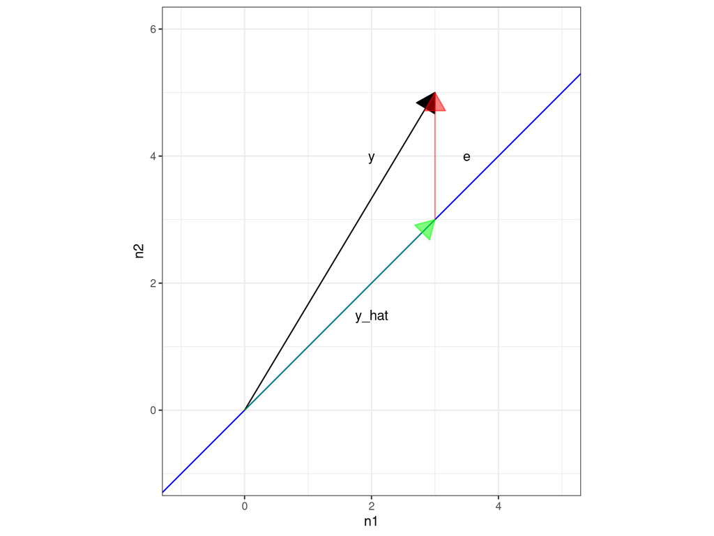

### Deriving the mean:

This means our goal is to minimize $\mathbf{e}$.

How do we find the closest distance? The length of $\mathbf{e}$ is calculated by taking:

$$len(\mathbf{e})= \sqrt{(3-\hat{y})^2 +
(5 - \hat{y})^2}$$

**When is the length of $\mathbf{e}$ minimized?**

- when angle between $\hat{y} \begin{pmatrix} 1 \\ 1 \end{pmatrix}$ and $\mathbf{e}$ is $90^{\circ}$.

### Deriving the mean:

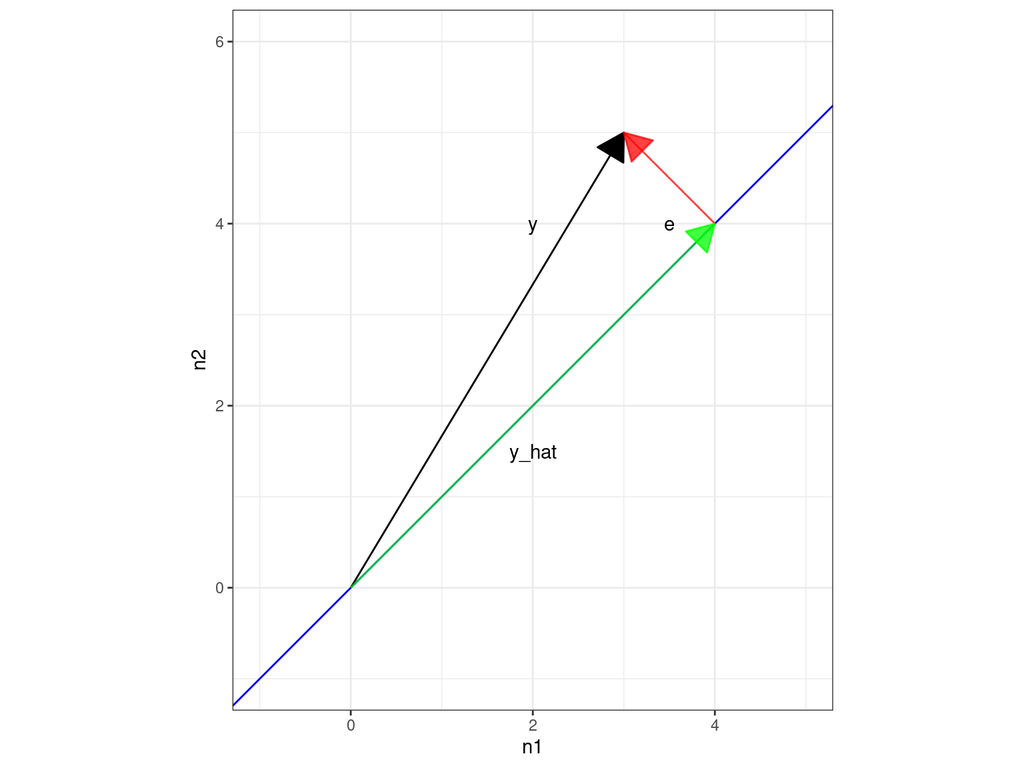

### Deriving the mean:

We know that two vector are orthogonal ($\perp$) when their dot product is $0$, so we can create the following equality and solve for $\hat{y}$.

$\mathbf{e} \bullet \begin{pmatrix} 1 \\ 1 \end{pmatrix} = 0$

$(\begin{pmatrix}3 & 5 \end{pmatrix} - \begin{pmatrix} \hat{y} & \hat{y} \end{pmatrix}) \bullet \begin{pmatrix} 1 \\ 1 \end{pmatrix} = 0$

$(\begin{pmatrix}3 & 5 \end{pmatrix} - \hat{y} \begin{pmatrix} 1 & 1 \end{pmatrix}) \bullet \begin{pmatrix} 1 \\ 1 \end{pmatrix} = 0$

### Deriving the mean:

$(\begin{pmatrix} 3 & 5 \end{pmatrix} \bullet \begin{pmatrix} 1 \\ 1 \end{pmatrix}) - (\hat{y} \begin{pmatrix} 1 & 1 \end{pmatrix} \bullet \begin{pmatrix} 1 \\ 1 \end{pmatrix}) = 0$

$(8) - (\hat{y} 2) = 0$

$8 = \hat{y} 2$

$4 = \hat{y}$

### Deriving the mean:

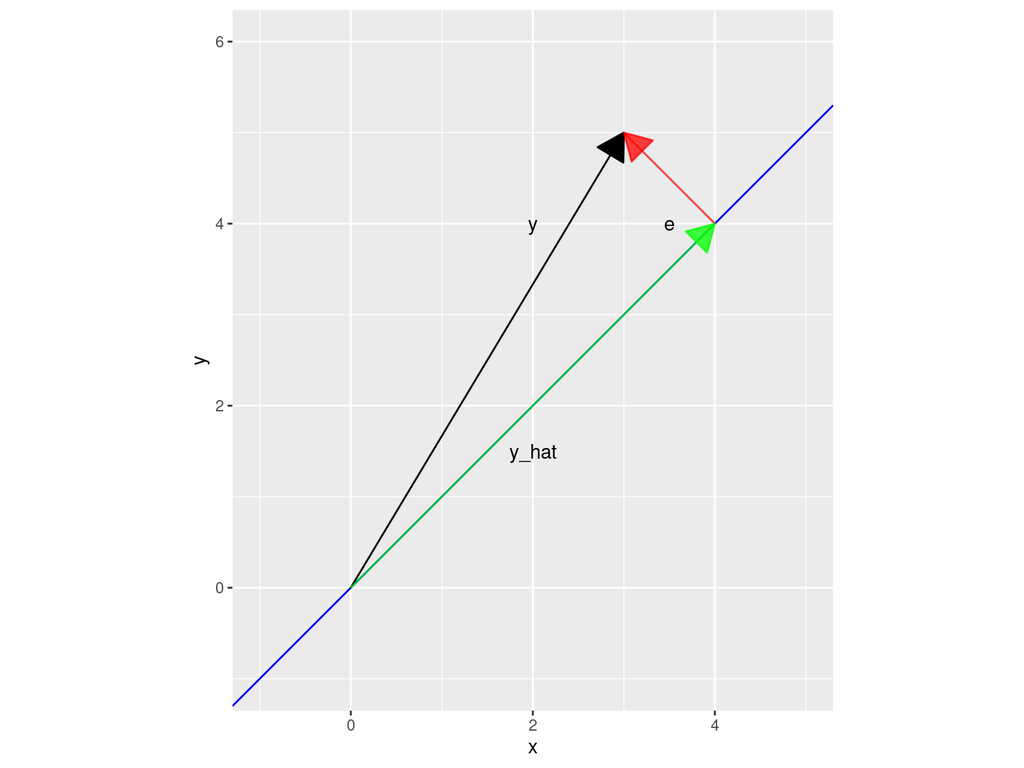

### More generally:

$\mathbf{e} \bullet \begin{pmatrix} 1 \\ \vdots \\ 1 \end{pmatrix} = 0$

$(\begin{pmatrix} y_1 & \ldots & y_n \end{pmatrix} - \begin{pmatrix} \hat{y} & \ldots & \hat{y} \end{pmatrix}) \bullet \begin{pmatrix} 1 \\ \vdots \\ 1 \end{pmatrix} = 0$

$(\begin{pmatrix} y_1 & \ldots & y_n \end{pmatrix} - \hat{y}\begin{pmatrix} 1 & \ldots & 1 \end{pmatrix}) \bullet \begin{pmatrix} 1 \\ \vdots \\ 1 \end{pmatrix} = 0$

### More generally:

$(\sum\limits_{i=1}^{n} y_i\cdot1) - \hat{y} \sum\limits_{i=1}^{n} 1 = 0$

$\sum\limits_{i=1}^{n} y_i = \hat{y} n$

$\frac{1}{n}\sum\limits_{i=1}^{n} y_i = \hat{y}$

### Deriving Least Squares

Regression works similarly:

Rather than project the $n \times 1$-dimensional vector $\mathbf{Y}$ into one dimension (as we did with the mean), we project it into $p$ (number of parameters) dimensional subspace. Hard to visualize, but we still end up minimizing the distance between our $n$ dimensional vector $\mathbf{\hat{Y}}$ and the vector $\mathbf{Y}$.

- If we have $n$ of $3$ and a bivariate regression, we find a $\mathbf{\hat{Y}}$ in $2$ dimensions that is nearest $\mathbf{Y}$

### Deriving Least Squares

Given $\mathbf{Y}$, an $n \times 1$ dimensional vector of all values $Y$ for $n$ observations

and $\mathbf{X}$, an $n \times p$ dimensional matrix ($p$ columns, $n$ observations). We call this the **design matrix**. Almost always includes a vector of $\mathbf{1}$ (for an intercept, or the mean)

$\mathbf{\hat{Y}}$ is an $n \times 1$ dimensional vector of predicted values (for the mean of Y conditional on X) computed by $\mathbf{X\beta}$. $\mathbf{\beta}$ is a vector $p\times 1$ of (parameters) that we multiply by $\mathbf{X}$.

We’ll assume there are only two parameters in $\mathbf{\beta}$: $a,b$ so that $Y_i = a + b \cdot X_i$, so $p = 2$

### Deriving Least Squares

$$\mathbf{X} = \begin{pmatrix} 1 & x_1
\\ \vdots & \vdots \\ 1 & x_n \end{pmatrix}; \mathbf{Y} =
\begin{pmatrix} y_1 \\ \vdots \\ y_n \end{pmatrix}; \beta =
\begin{pmatrix} a \\ b \end{pmatrix}$$

### Deriving Least Squares

$$\widehat{Y_i} = a + b \cdot
x_i$$

$$\widehat{Y}_{n \times 1} = \mathbf{X}_{n
\times p}\beta_{p \times 1}$$

$$\begin{pmatrix} 1 & x_1 \\ \vdots
& \vdots \\ 1 & x_n \end{pmatrix} \begin{pmatrix} a \\ b
\end{pmatrix} = \widehat{Y} = \begin{pmatrix} \hat{y_1} \\ \vdots \\
\hat{y_n} \end{pmatrix}$$

$\mathbf{e} = \mathbf{Y} - \mathbf{\hat{Y}}$ gives us the residuals.

### Deriving Least Squares

We want to choose $\mathbf{\beta}$ or $a,b$ such that the distance between $\mathbf{Y}$ and $\mathbf{\hat{Y}}$ is minimized. Or sum of squared residuals is minimized.

Like before, the distance is minimized when the vector of **residuals** $\mathbf{Y} - \mathbf{\hat{Y}} = \mathbf{e}$ is $\perp$ to $\mathbf{X}$

## Deriving Least Squares

$\mathbf{X}'_{p\times n}\mathbf{e}_{n\times1} = \begin{pmatrix} 0_1 \\ \vdots \\ 0_p \end{pmatrix} = \mathbf{0}_{p \times 1}$

$\mathbf{X}'(\mathbf{Y} - \mathbf{\hat{Y}}) = \mathbf{0}_{p \times 1}$

$\mathbf{X}'(\mathbf{Y} - \mathbf{X{\beta}}) = \mathbf{0}_{p \times 1}$

$\mathbf{X}'\mathbf{Y} - \mathbf{X}'\mathbf{X{\beta}} = \mathbf{0}_{p \times 1}$

$\mathbf{X}'\mathbf{Y} = \mathbf{X}'\mathbf{X{\beta}}$

$(\mathbf{X}'\mathbf{X})^{-1}\mathbf{X}'\mathbf{Y} = \mathbf{{\beta}}$

### Deriving Least Squares

$$(\mathbf{X}'\mathbf{X})^{-1}\mathbf{X}'\mathbf{Y}
= \mathbf{{\beta}}$$

This is the matrix formula for **least squares** regression.

If $X$ is a column vector of $1$s, $\beta$ is just the mean of $Y$. (We just did this)

If $X$ is a column of $1$s and a column of $x$s, it is bivariate regression.

We can now add $p >2$: more variables

### Example:

```r
n = 5
x = rep(1, 5)
y = c(1,2,1,6,3)

#(x'x)^-1 x'y
#t() gives transpose
#solve() gives inverse
#%*% is matrix/vector multiplication
solve(t(x) %*% x) %*% t(x) %*% y
```

```
##      [,1]
## [1,]  2.6
```

```r
#mean of y
mean(y)
```

```
## [1] 2.6
```

### Example:

Let’s do bivariate regression:

$Y_i = a + b \cdot x_i$

$$\mathbf{X} = \begin{pmatrix} 1 & x_1
\\ \vdots & \vdots \\ 1 & x_n \end{pmatrix}; \mathbf{Y} =
\begin{pmatrix} y_1 \\ \vdots \\ y_n \end{pmatrix}$$

Take $x = 0,2,4,6,8,10$, $y = 0, 12, 21, 31, 40, 50$

Solve for $a$ and $b$ using $b = \frac{Cov(x,y)}{Var(x)}$ and $a = \bar{y} - b \bar{x}$ Solve for $a$ and $b$ using the matrix calculation.

```r
x = c(0,2,4,6,8,10)
y = c(0, 12, 21, 31, 40, 50)

#Version 1
b_1 = cov(x,y)/var(x)
a_1 = mean(y) - mean(x)*b_1

#Version 2
X = cbind(1, x)
beta = solve(t(X) %*% X) %*% t(X) %*% y

#Estimates
c(a_1, b_1)
```

```
## [1] 1.095238 4.914286
```

```r
beta
```

```
##       [,1]
##   1.095238
## x 4.914286
```

### Just what are the matrices doing?

But we also want to know more intuitively what these matrix operations are doing! It isn’t **magic**.

- We will walk through what exactly the matrix calculations do for us.

### $(\mathbf{X}'\mathbf{X})^{-1}\mathbf{X}'\mathbf{Y} = \mathbf{{\beta}}$

$$\mathbf{X} = \begin{pmatrix} 1 & x_1
\\ \vdots & \vdots \\ 1 & x_n \end{pmatrix}; \mathbf{Y} =
\begin{pmatrix} y_1 \\ \vdots \\ y_n \end{pmatrix}$$

$$\mathbf{X}'\mathbf{X} =
\begin{pmatrix} 1 & \ldots & 1 \\ x_1 & \ldots & x_n
\end{pmatrix} \begin{pmatrix} 1 & x_1 \\ \vdots & \vdots \\ 1
& x_n \end{pmatrix}$$

$$= \begin{pmatrix} n & \sum_i x_i \\
\sum_i x_i & \sum_i x_i^2 \end{pmatrix} = n \begin{pmatrix} 1 &
\overline{x} \\ \overline{x} & \overline{x^2}
\end{pmatrix}$$

### $(\mathbf{X}'\mathbf{X})^{-1}\mathbf{X}'\mathbf{Y} = \mathbf{{\beta}}$

$$\mathbf{X} = \begin{pmatrix} 1 & x_1
\\ \vdots & \vdots \\ 1 & x_n \end{pmatrix}; \mathbf{Y} =
\begin{pmatrix} y_1 \\ \vdots \\ y_n \end{pmatrix}$$

$$\mathbf{X}'\mathbf{Y} =
\begin{pmatrix} 1 & \ldots & 1 \\ x_1 & \ldots & x_n
\end{pmatrix} \begin{pmatrix} y_1 \\ \vdots \\ y_n
\end{pmatrix}$$
$$=
\begin{pmatrix} \sum_i y_i \\ \sum_i x_i y_i \end{pmatrix} = n
\begin{pmatrix} \overline{y} \\ \overline{xy} \end{pmatrix}$$

## Inverting Matrices

How do we get $^{-1}$? This is **inverting** a matrix.

- Inverse $A^{-1}$ of matrix $A$ that is **square** or $p\times p$ has the property:

$$A \times A^{-1} = A^{-1} \times A = I_{p
\times p} = \begin{pmatrix} 1 & 0 & \ldots & 0 \\ 0 &
\ddots & \ldots & 0 \\ 0 & \ldots & \ddots & 0 \\ 0
& \ldots & 0 & 1 \end{pmatrix}$$

This is an **identity** matrix with 1s on diagonal, 0s everywhere else.

## Inverting Matrices

We need to get the **determinant**

For sake of ease, will show for a scalar and for a $2 \times 2$ matrix:

$$det(a) = a$$

$$det\begin{pmatrix} a & b \\ c &
d \end{pmatrix} = ad - cb$$

## Inverting Matrices

Then we need to get the **adjoint**. It is the transpose of the matrix of cofactors (don’t ask me why):

$$adj(a) = 1$$

$$adj\begin{pmatrix} a & b \\ c &
d \end{pmatrix} = \begin{pmatrix} d & -b \\ -c & a
\end{pmatrix}$$

## Inverting Matrices

The inverse of $A$ is $adj(A)/det(A)$

$$A^{-1} = \frac{1}{ad -
cb}\begin{pmatrix} d & -b \\ -c & a \end{pmatrix}$$

### Deriving Least Squares

$$A^{-1} = \frac{1}{ad -
cb}\begin{pmatrix} d & -b \\ -c & a \end{pmatrix}$$

$$(\mathbf{X}'\mathbf{X}) = n
\begin{pmatrix} 1 & \overline{x} \\ \overline{x} &
\overline{x^2} \end{pmatrix}$$

$$(\mathbf{X}'\mathbf{X})^{-1} =
\frac{n}{n^2(\overline{x^2} - \overline{x}^2)} \begin{pmatrix}
\overline{x^2} & -\overline{x} \\ -\overline{x} & 1
\end{pmatrix}$$

$$(\mathbf{X}'\mathbf{X})^{-1} =
\frac{1}{n \cdot Var(x)} \begin{pmatrix} \overline{x^2} &
-\overline{x} \\ -\overline{x} & 1 \end{pmatrix}$$

### Deriving Least Squares

We can put it together to get: $(\mathbf{X}'\mathbf{X})^{-1}\mathbf{X}'\mathbf{Y} = \mathbf{{\beta}}$

$$(\mathbf{X}'\mathbf{X})^{-1}\mathbf{X}'\mathbf{Y}
= \frac{1}{n \cdot Var(x)} \begin{pmatrix} \overline{x^2} &
-\overline{x} \\ -\overline{x} & 1 \end{pmatrix} \frac{n}{1}
\begin{pmatrix} \overline{y} \\ \overline{xy} \end{pmatrix}$$

$$(\mathbf{X}'\mathbf{X})^{-1}\mathbf{X}'\mathbf{Y}
= \frac{1}{Var(x)} \begin{pmatrix} \overline{x^2}\overline{y}
-\overline{x} \ \overline{xy} \\ \overline{xy} - \overline{x}\
\overline{y}\end{pmatrix} = \begin{pmatrix}a \\ b
\end{pmatrix}$$

### Deriving Least Squares

The slope:

$$\beta = \frac{1}{Var(x)} \begin{pmatrix}
\overline{x^2}\overline{y} -\overline{x} \ \overline{xy} \\
\overline{xy} - \overline{x} \ \overline{y}\end{pmatrix} =
\begin{pmatrix}a \\ b \end{pmatrix}$$

$$b = \frac{\overline{xy} - \overline{x} \
\overline{y}}{Var(x)} = \frac{Cov(x,y)}{Var(x)}$$

$$b = \frac{Cov(x,y)}{Var(x)} = r
\frac{SD_y}{SD_x}$$

### Deriving Least Squares

The slope:

- Expresses how much mean of $Y$ changes for a 1-unit change in $X$

### The Intercept:

$$\beta = \frac{1}{Var(x)} \begin{pmatrix}
\overline{x^2}\overline{y} -\overline{x} \ \overline{xy} \\
\overline{xy} - \overline{x} \ \overline{y}\end{pmatrix} =
\begin{pmatrix}a \\ b \end{pmatrix}$$

$$a = \frac{\overline{x^2}\overline{y}
-\overline{x} \ \overline{xy}}{Var(x)} = \frac{(Var(x) +
\overline{x}^2)\overline{y} - \overline{x}(Cov(x,y) +
\overline{x}\overline{y})}{Var(x)}$$

$$= \frac{Var(x)\overline{y} +
\overline{x}^2\overline{y} - \overline{x}^2\overline{y} -
\overline{x}Cov(x,y)}{Var(x)}$$

$$= \overline{y} -
\overline{x}\frac{Cov(x,y)}{Var(x)}$$

$$a = \overline{y} - \overline{x}\cdot
b$$

### Deriving Least Squares

The Intercept:

$$a = \overline{y} - \overline{x}\cdot
b$$

Shows us that at $\bar{x}$, the line goes through $\bar{y}$. The regression line (of predicted values) goes through the point $(\bar{x}, \bar{y})$ or the point of averages.

### Key facts about regression:

The mathematical procedures we use in regression ensure that:

$1$. **the mean of the residuals is always zero** (if we include an intercept). Because we included an intercept ($a$), and the regression line goes through the point of averages, the mean of the **residuals** is always 0. $\overline{e} = 0$. This is also true of residuals of the mean.

### Why?

**the mean of the residuals is always zero**.

We choose $\begin{pmatrix}a \\ b \end{pmatrix}$ such that $e$ is orthogonal to $\mathbf{X}$. One column of $\mathbf{X}$ is all $1$s, to get the intercept (recall how we used vectors to get the mean). So $e$ is orthogonal to $\begin{pmatrix} 1 \\ \vdots \\ 1 \end{pmatrix}$.

$$\mathbf{1}'e = 0$$

And if this is true, the $\sum e_i = 0$ so $\frac{1}{n}\sum e_i = 0$.

### Key facts about regression:

The mathematical procedures we use in regression ensure that:

$2$. $Cov(X,e) = 0$. This is true by definition of how we derived least squares.

Recall that $Cov(X,e) = \overline{xe}-\overline{x} \ \overline{e}$

We chose $\beta$ ($a,b$) such that $X'e = 0$ so they would be **orthogonal**.

$X'e = 0 \to \sum x_ie_i = 0 \to \overline{xe}=0$;

And, from above, we know that $\overline{e}=0$;

so $Cov(X,e) = \overline{xe}-\overline{x} \ \overline{e} = 0 - \overline{x}0 = 0$.

$2$. $Cov(X,e) = 0$. This is true by definition of how we derived least squares.

This **also means** that residuals $e$ are **always** perfectly uncorrelated (Pearson correlation) with **all** the columns in our matrix $\mathbf{X}$: all the variables we include in the regression model.

# Multivariate Least Squares

### Multivariate Least Squares:

Previously we fit the mean of $Y$ as a linear function of $X$:

$$Y_i = a + b \cdot X_i$$

Now, we can imagine fitting mean of $Y$ as a linear function of many variables:

$$Y_i = b_0 + b_1 X_1 + b_2 X_2 + \ldots +
b_k X_k$$

### Multivariate Least Squares:

- When we calculated the mean using matrix algebra, we projected the $n$ dimensional vector $Y$ onto a point on a one-dimensional line.
- When we calculated the bivariate regression line, we projected the $n$ dimensional vector $Y$ onto a $2$-dimensional space (one for $a$ and one for $b$)
- When we use multi-variate regression, we project the $n$ dimensional vector $Y$ onto a $p$ dimensional space (one for each parameter/coefficient)

### Multivariate Least Squares:

What is “projecting onto $p$ dimensions”

When we project into two dimensions, these dimensions are **precisely like** the $x$ and $y$ axes on a graph: perpendicular/orthogonal to each other.

In multivariate regression, because we are going to project $Y$ onto $p$ **orthogonal** dimensions in $\mathbf{X}$.

- “under the hood”, regression creates a new version of $\mathbf{X}$ where each column is **orthogonal to the others**

### Mathematical Requirements:

1. Matrix $X$ has “full rank”
- This means that all of the columns of $\mathbf{X}$ are **linearly independent**.
  - cannot have two identical columns
  - cannot have set of columns that sum up to another column multiplied by a scalar
- If $\mathbf{X}$ is not full rank, cannot be inverted, cannot do least squares.
  - but we’ll see more on the intuition for this later.
2. $n \geq p$: we need to have more data points than variables in our equation
- no longer trivial with multiple regression

### Multivariate Least Squares:

Examples: **Linear Dependence**?

| 1 | 1 | 0 | 0 |
| --- | --- | --- | --- |
| 1 | 0 | 1 | 0 |
| 1 | 0 | 0 | 1 |

## Multivariate Least Squares:

Examples: **Linear Dependence**?

| 1 | 2 | 0 | 0 |
| --- | --- | --- | --- |
| 1 | 0 | 2 | 0 |
| 1 | 0 | 0 | 2 |

## Multivariate Least Squares:

Examples: **Linear Dependence**?

| 1 | 0.50 | 0.25 | 0.25 |
| --- | --- | --- | --- |
| 1 | 0.25 | 0.50 | 0.25 |
| 1 | 0.25 | 0.25 | 0.50 |

### Multivariate Least Squares:

When we include more than one variable in the equation, we cannot calculate slopes using simple algebraic expressions like $\frac{Cov(X,Y)}{Var(X)}$.

- Must use matrix algebra (this is why I introduced it)

We calculate least squares using same matrix equation ($(X'X)^{-1}X'Y$) as in bivariate regression, but what is the math **doing** in the multivariate case?

### Multivariate Least Squares:

When fitting the equation:

$Y_i = b_0 + b_1x_i + b_2z_i + e_i$

1. $b_1 = \frac{Cov(x^*, Y)}{Var(x^*)}$

Where $x^* = x - \hat{x}$ from the regression: $\hat{x} = c_0 + c_1 z$.

2. $b_2 = \frac{Cov(z^*, Y)}{Var(z^*)}$

Where $z^* = z - \hat{z}$ from the regression: $\hat{z} = d_0 + d_1 x$

Does anything look familiar here?

### Multivariate Least Squares:

More generally:

$$Y = b_0 + b_1 X_1 + b_2 X_2 + \ldots +
b_k X_k$$

$b_k = \frac{Cov(X_k^*, Y)}{Var(X_k^*)}$

where $X_k^* = X_k - \hat{X_k}$ obtained from the regression:

$X_{k} = c_0 + c_1 x_{1} + \ldots + c_{j} X_{j}$

$X_k^*$ is the residual from regressing $X_k$ on all other $\mathbf{X_{j \neq k}}$

### Multivariate Least Squares:

How do we make sense of $X_k^*$ as residual $X_k$ after regressing on all other $\mathbf{X_{j \neq k}}$?

- It is the residual in same way as $e$: $X_k^*$ is **orthogonal** to all other variables in $\mathbf{X_{j \neq k}}$.
  - it is “perpendicular” to other variables, as are axes on a graph.
  - It is perfectly **uncorrelated** (in the linear sense) with all other variables in the regression.

### Multivariate Least Squares:

How do we make sense of $b_k = \frac{Cov(X_k^*, Y)}{Var(X_k^*)}$ (if $X_k^*$ as residual $X_k$ after regressing on all other $\mathbf{X_{j \neq k}}$?)

- The slope $b_k$ is the change in $Y$ with a one-unit change in the part of $X_k$ that is **uncorrelated with**/**orthogonal to** the other variables in the regression.

### Multivariate Least Squares:

How do we make sense of $b_k = \frac{Cov(X_k^*, Y)}{Var(X_k^*)}$ (if $X_k^*$ as residual $X_k$ after regressing on all other $\mathbf{X_{j \neq k}}$?)

- Sometimes people say “the slope of $X_k$ **controlling** for variables $\mathbf{X_{j \neq k}}$”.
  - is it “holding other factors constant”/*ceteris parabis*? Not quite.
  - better to think of it as “partialling out” the relationship with other variables in $\mathbf{X}$. The $X_k$ that does not covary with other variables

### Multivariate Least Squares:

There are additional implications of defining the slope $b_k = \frac{Cov(X_k^*, Y)}{Var(X_k^*)}$:

Now we can see why columns of $X$ must be linearly independent:

- e.g. if $X_1$ were linearly dependent on $X_2$ and $X_3$, then $X_2$ and $X_3$ *perfectly predict* $X_1$.
- If $X_1$ is perfectly predicted by $X_2$ and $X_3$, then the residuals $X_1^*$ will all be $0$.
- If $X_1^*$ are all $0$s, then $Var(X_k^*) = 0$, and $b_k$ is undefined.

### Exercise

```r
set.seed(1234)
n = 1000
u = rnorm(n)
x = u + rnorm(n, sd = 0.5)
z = sqrt(u^2) + rnorm(n, sd = 0.5)
y = 0 + 1*x - z^2  +  rnorm(n)
```

Generate the data using code above.

### Exercise

In `R`:

1. Create the design matrix $X$ to estimate $Y_i = b_0 + b_1 x_i + b_2 z_i$
2. Use the matrix equation for least squares to obtain $\beta$ ($b_0, b_1, b_2$)
3. Calculate $x^*$ as $x_i - \hat{x}_i$, where $\hat{x}_i$ comes from regressing $x$ on an intercept and $z$.
4. What is the correlation of $x^*$ and $z$?
5. Plot $x^*$ and $z$
6. Is $x^*$ **independent** of $z$?